# Early Earth — figures and the story they tell

**What we want readers to see:** short quenches change observed connectivity; large structural variety coexists with an abundant core of small, recurrent fragments. The manuscript opens with energy history and alanine geometry; this notebook develops the quench and structural-coverage evidence that follows.

**Advisor reading path:** quench response → the same atoms → variety versus abundance → rare versus recurrent. Stop after those four figures for a short review. Additional candidates are available for figure selection.

A **fragment** is a connected component, including isolated atoms; sizes include H. A **distinct emitted string** is a representation of connectivity, not a verified chemical species. All figures are working candidates awaiting author/advisor selection.

## 1. How does a short quench change fragment size? — F12/F13

**Point:** mean size rises in 3,439 of 3,521 pairs; the largest component rises in 2,812. Mean size is total atoms divided by component count; largest size is an individual-component maximum. The lower panels show paired changes.

**Scope:** every point is one of 3,521 independent 25-fs endpoints from the 22.8M-atom system. The dotted line marks the restart; endpoints do not form a cooling trajectory.

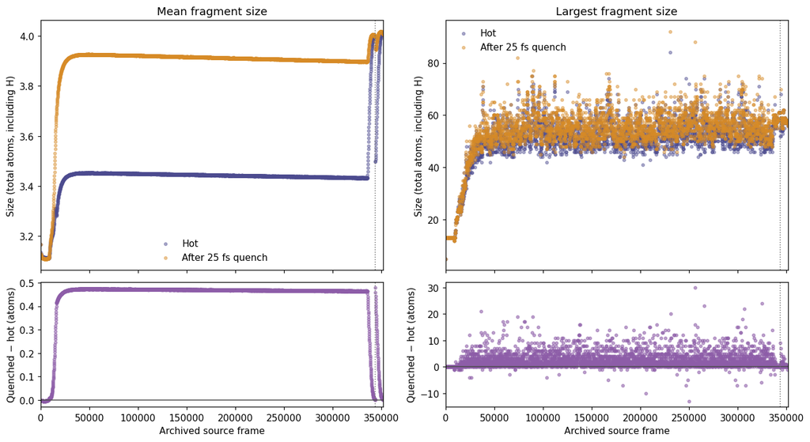

## 2. What does a connectivity change look like? — F14

**Point:** the same ten atom IDs go from a nine-atom component plus isolated H to one ten-atom component. Purple highlights the added C–H cutoff connection; its true 3D distance changes from 1.3150 to 1.0929 Å.

**Scope:** selected logical frame 447 (source frame 44,700), rigidly aligned without reflection and shown on a common projection/scale. This illustrates connectivity, without assigning a reaction mechanism or electronic state.

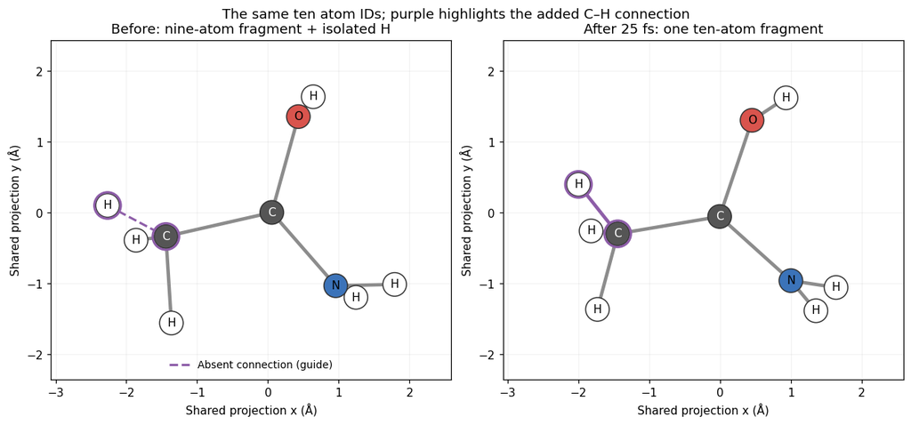

## 3. Which sizes supply variety, and which supply abundance? — F17

**Point:** median size is 23 atoms when each distinct string counts once, but 3 atoms when each fragment occurrence counts; 90% of occurrences have at most 5 atoms.

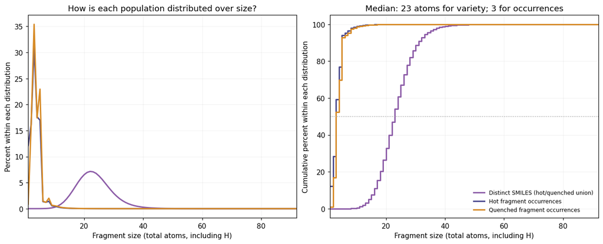

## 4. Is structural variety repeatedly observed? — F18

**Point:** 74.48% of carbon-containing strings appear in one sampled frame pair; strings seen in at least 1,000 pairs supply over 99.5% of carbon-fragment occurrences.

**Scope:** recurrence counts presence in either state across 3,521 sampled pairs. Each bar series has its own carbon-containing denominator. Recurrence is sampled presence, not continuous lifetime or stability.

**Pause for advisor review:** which of these four points deserves a main-text panel, and which belongs in supporting information?

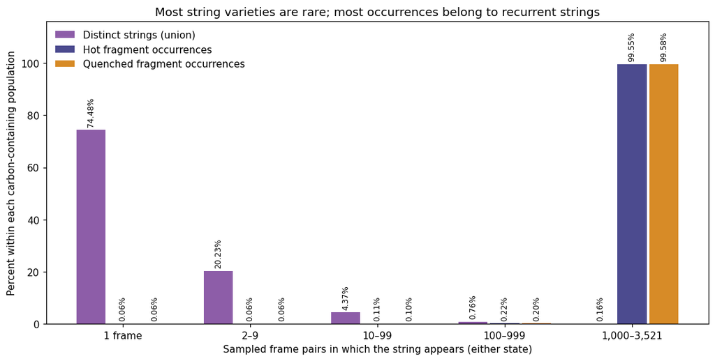